### Visualizing a Factor Plot with Only Global Factor Scores

For clustering, it is useful to look at global factor scores without block factor scores. The `projection_plot()` function can be used to generate such a plot using `plotType="projection_global"` as show below:

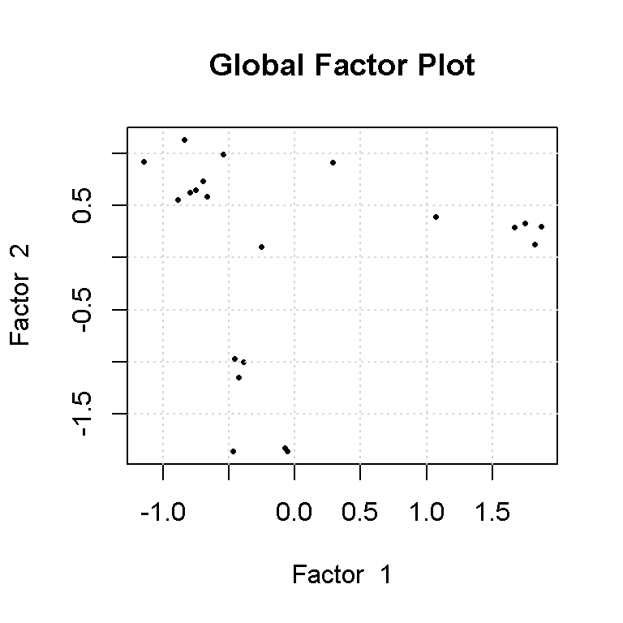

```r
projection_plot(mcia_results, "projection_global", orders = c(1,2))
```

In addition, factor plots are most helpful when points are colored by a meaningful label such as cancer type. The `projection_plot()` function can include such data using the `metadata` argument. The `metadata` arguments requires a data frame where rows are samples and columns are different labels, allowing for a variety of visualization objectives/explorations. For instance, each of the 21 samples in the NCI-60 dataset represents a patient with one of three cancer types: CNS, Leukemia, or Melanoma. We have provided this metadata as part of the `data(NCI60)` datasets and can be found as `metadata_NCI60`:

```r
metadata_NCI60
```

```
##               cancerType
## CNS.SF_268           CNS
## CNS.SF_295           CNS
## CNS.SF_539           CNS
## CNS.SNB_19           CNS
## CNS.SNB_75           CNS
## CNS.U251             CNS
## LE.CCRF_CEM     Leukemia
## LE.HL_60        Leukemia
## LE.K_562        Leukemia
## LE.MOLT_4       Leukemia
## LE.RPMI_8226    Leukemia
## LE.SR           Leukemia
## ME.LOXIMVI      Melanoma
## ME.MALME_3M     Melanoma
## ME.M14          Melanoma
## ME.SK_MEL_2     Melanoma
## ME.SK_MEL_28    Melanoma
## ME.SK_MEL_5     Melanoma
## ME.UACC_257     Melanoma
## ME.UACC_62      Melanoma
## ME.MDA_MB_435   Melanoma
```

In order to use this data it must be converted into a data frame and passed as part of the `metadata` argument of `nipals_multiblock()` or added directly to `mcia_results`:

```r
# Conversion of metadata to data frame
metadata_NCI60 <- data.frame(cancerType = unlist(metadata_NCI60))
row.names(metadata_NCI60) <- rownames(data_blocks[[1]])

# Adding metadata as part of the nipals_multiblock() function
mcia_results <- nipals_multiblock(data_blocks, preprocMethod = "colprofile",
                                  metadata = metadata_NCI60, plots = "none",
                                  num_PCs = 10, tol = 1e-12)

# Alternative method for adding metadata
mcia_results$metadata <- metadata_NCI60
```

The `coloring` argument of `projection_plot()` can then be used to determine which column of `metadata` is used for coloring the projection plots, in this case the column is `cancerType`:

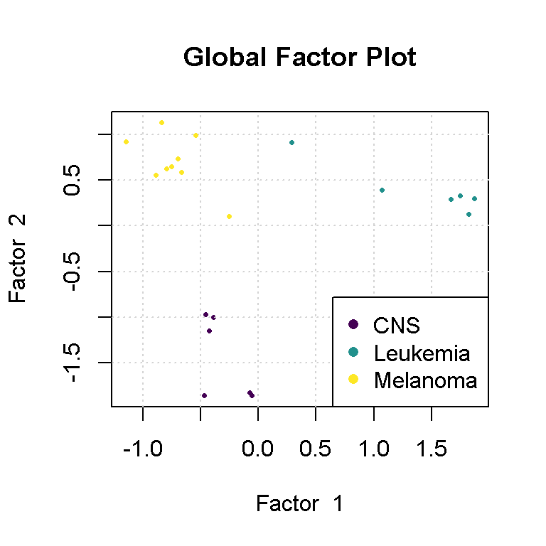

```r
projection_plot(mcia_results, "projection_global", orders = c(1,2),
                coloring = "cancerType", legend_loc = "bottomright")
```

Clusters of samples can be computed from the global factor scores using any method, such as k-means clustering and visualized similarly.